# Part I - Ford Go Bike Data Exploration

## Introduction

According to [Wiki/BayWheels](https://en.wikipedia.org/wiki/Bay_Wheels), Bay Wheels is the first regional public bicycle sharing system in the U.S. that services more than just a single city or adjacent cities.On June 28, 2017, the system officially re-launched as Ford GoBike. Coinciding with the expansion and rebranding as Ford GoBike, several new programs such as integration with Clipper cards and a low-income pricing option were launched. Ford GoBike expanded electric bicycles by 250. In 2018, the Bay Wheels system reached around 10,000 annual subscribers, over 2,600 bicycles in 262 stations across San Francisco, East Bay and San Jose. However, in 2019 the system rebranded to Bay Wheels and dropped the Ford naming, with funding motivation of another company.

## Preliminary Wrangling

The Ford GoBike data set includes information about individual rides made in a bike-sharing system covering the greater San Francisco Bay area. Each rows in the data represents a user's trip.

In this analysis, I would like to see how Ford GoBike expanded this system, and will answer these questions:

- When are most trips taken in terms of time of day and day of the week?
- How long does the average trip take?
- Does the above depend on if a user is a subscriber or customer?
- Does the above depend on user's gender?
- What age group rides bikes the most?
- What is the relation between these variables?

# Importing packages

```python
import numpy as np
import pandas as pd
import matplotlib.pyplot as plt
import seaborn as sb

%matplotlib inline
```

# Loading dataset

```python
#loading csv dataset
df = pd.read_csv("201902-fordgobike-tripdata.csv")
df.head(3)
```

|  | duration_sec | start_time | end_time | start_station_id | start_station_name | start_station_latitude | start_station_longitude | end_station_id | end_station_name | end_station_latitude | end_station_longitude | bike_id | user_type | member_birth_year | member_gender | bike_share_for_all_trip |
| --- | --- | --- | --- | --- | --- | --- | --- | --- | --- | --- | --- | --- | --- | --- | --- | --- |
| 0 | 52185 | 2019-02-28 17:32:10.1450 | 2019-03-01 08:01:55.9750 | 21.0 | Montgomery St BART Station (Market St at 2nd St) | 37.789625 | -122.400811 | 13.0 | Commercial St at Montgomery St | 37.794231 | -122.402923 | 4902 | Customer | 1984.0 | Male | No |
| 1 | 42521 | 2019-02-28 18:53:21.7890 | 2019-03-01 06:42:03.0560 | 23.0 | The Embarcadero at Steuart St | 37.791464 | -122.391034 | 81.0 | Berry St at 4th St | 37.775880 | -122.393170 | 2535 | Customer | NaN | NaN | No |
| 2 | 61854 | 2019-02-28 12:13:13.2180 | 2019-03-01 05:24:08.1460 | 86.0 | Market St at Dolores St | 37.769305 | -122.426826 | 3.0 | Powell St BART Station (Market St at 4th St) | 37.786375 | -122.404904 | 5905 | Customer | 1972.0 | Male | No |

- The data includes 183.412 rows and 16 columns which include both categorical and numeric features. The data is in a csv format.
- As my main interest, I will focus on the customer informations because I am wondering which people mostly prefer renting a bike, how they can be classified. It is important to know the customer for marketing side.

> user_type (subscriber:member or customer:ordinary user)

> member_gender

> member_birth_year (age)
- Also, I will indestigate the details of the trips. I believe that it is important to understan which stations most popular, how long do people rent a car and the attitude of the users about leaving bikes whether to the same station back or what is the route mostly used for a trip. These are all significant for pricing and profit side.

> duration_sec (how long does these bike preferred to use) : duration_minutes

> start_station_name (which stations are mostly used for renting)

> start_time : duration_day & duration_hour

## Exploration

```python
#copy the original dataset to work clean
df_ford = df.copy()
df_ford.info()
```

```
<class 'pandas.core.frame.DataFrame'>
RangeIndex: 183412 entries, 0 to 183411
Data columns (total 16 columns):
 #   Column                   Non-Null Count   Dtype
---  ------                   --------------   -----
 0   duration_sec             183412 non-null  int64
 1   start_time               183412 non-null  object
 2   end_time                 183412 non-null  object
 3   start_station_id         183215 non-null  float64
 4   start_station_name       183215 non-null  object
 5   start_station_latitude   183412 non-null  float64
 6   start_station_longitude  183412 non-null  float64
 7   end_station_id           183215 non-null  float64
 8   end_station_name         183215 non-null  object
 9   end_station_latitude     183412 non-null  float64
 10  end_station_longitude    183412 non-null  float64
 11  bike_id                  183412 non-null  int64
 12  user_type                183412 non-null  object
 13  member_birth_year        175147 non-null  float64
 14  member_gender            175147 non-null  object
 15  bike_share_for_all_trip  183412 non-null  object
dtypes: float64(7), int64(2), object(7)
memory usage: 22.4+ MB
```

I added new columns for duration duration_day, duration_hour and duration_minutes.

```python
#the day of trip calculation
df_ford['duration_day'] = pd.to_datetime(df_ford['start_time']).dt.day_name()
```

```python
# starting hour of trip calculation
df_ford['duration_hour'] = pd.to_datetime(df_ford['start_time']).dt.hour
```

```python
# duration length in minutes calculation
df_ford['duration_minutes'] = df_ford['duration_sec'] // 60
```

I added a column for member age, base year selected as 2019.

```python
# member age calculation
df_ford['member_age'] = 2019 - df_ford['member_birth_year']
```

There are some irrelavent birth years in the data, I assumed that someone older than 80 years old cannot ride a bike.

```python
#Cleaning member birth year < 1939
df_ford.drop(df_ford[df_ford.member_birth_year < 1939].index, inplace=True)
df_ford.member_birth_year.min()
```

```
1939.0
```

Test for data coverage:

```python
#Data covarage calculation
data_coverage = pd.DataFrame(((df_ford.count()-df_ford.isnull().sum())/df_ford.count())*100 , columns=['Data Coverage'])
data_coverage
```

|  | Data Coverage |
| --- | --- |
| duration_sec | 100.000000 |
| start_time | 100.000000 |
| end_time | 100.000000 |
| start_station_id | 99.892363 |
| start_station_name | 99.892363 |
| start_station_latitude | 100.000000 |
| start_station_longitude | 100.000000 |
| end_station_id | 99.892363 |
| end_station_name | 99.892363 |
| end_station_latitude | 100.000000 |
| end_station_longitude | 100.000000 |
| bike_id | 100.000000 |
| user_type | 100.000000 |
| member_birth_year | 95.275928 |
| member_gender | 95.275928 |
| bike_share_for_all_trip | 100.000000 |
| duration_day | 100.000000 |
| duration_hour | 100.000000 |
| duration_minutes | 100.000000 |
| member_age | 95.275928 |

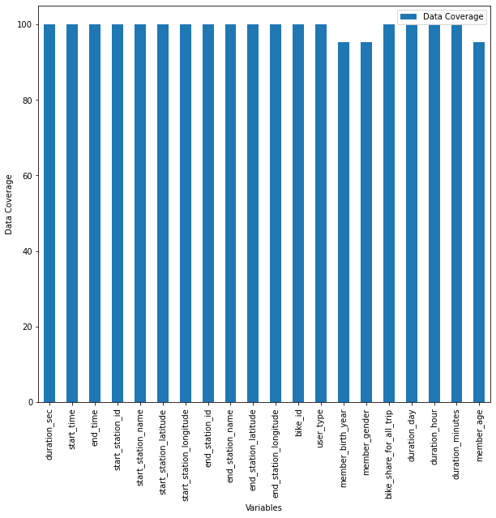

```python
#Data coverage visualization
ax = data_coverage.plot(kind = 'bar' , figsize = (10,9))
ax.set(xlabel = 'Variables' , ylabel = 'Data Coverage')

plt.show()
```

The data looks normal, let's look for the null values.

```python
#null values
null_values = df_ford.isnull().sum()
null_values
```

```
duration_sec                  0
start_time                    0
end_time                      0
start_station_id            197
start_station_name          197
start_station_latitude        0
start_station_longitude       0
end_station_id              197
end_station_name            197
end_station_latitude          0
end_station_longitude         0
bike_id                       0
user_type                     0
member_birth_year          8265
member_gender              8265
bike_share_for_all_trip       0
duration_day                  0
duration_hour                 0
duration_minutes              0
member_age                 8265
dtype: int64
```

```python
#null value cleaning and check
na_counts = df_ford.drop(['start_station_id', 'start_station_name', 'end_station_id', 'end_station_name', 'member_birth_year', 'member_gender', 'member_age'], axis=1).isna().sum()
na_counts
```

```
duration_sec               0
start_time                 0
end_time                   0
start_station_latitude     0
start_station_longitude    0
end_station_latitude       0
end_station_longitude      0
bike_id                    0
user_type                  0
bike_share_for_all_trip    0
duration_day               0
duration_hour              0
duration_minutes           0
dtype: int64
```

## Univariate Exploration

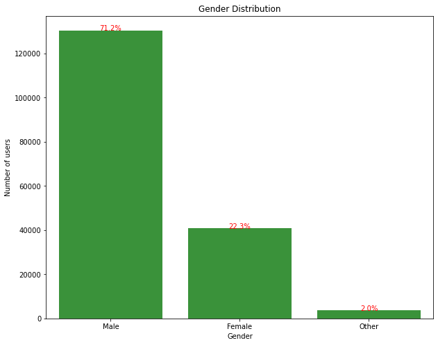

```python
# distribution of gender visualization
plt.figure(figsize=[10, 8])

base_color = sb.color_palette()[2]
gender_order = df_ford['member_gender'].value_counts().index
sb.countplot(data = df_ford, x = 'member_gender', color = base_color, order=gender_order)
plt.title('Gender Distribution')
plt.xlabel('Gender')
plt.ylabel('Number of users')

#frequencies of gender distribution
n_points = df_ford.shape[0]
gender_counts = df_ford['member_gender'].value_counts()
locs, labels = plt.xticks()

for loc, label in zip(locs, labels):
    count = gender_counts[label.get_text()]
    pct_string = '{:0.1f}%'.format(100*count/n_points)
    plt.text(loc, count-8, pct_string, ha='center', color='r')

plt.show()
```

Male proportion is about 71% while female proportion is approximately 22%. The plot shows that males are using the system more frequently.

```python
#user_type counts and order
user_type_counts = df_ford['user_type'].value_counts()
user_type_order = user_type_counts.index
user_type_order
```

```
Index(['Subscriber', 'Customer'], dtype='object')
```

```python
# user proportion rate calculations
n_df_ford = df_ford.shape[0]
subscriber_user_type_count = user_type_counts[0]
subscriber_user_type_prop = subscriber_user_type_count / n_df_ford
customer_user_type_count = user_type_counts[1]
customer_user_type_prop = customer_user_type_count / n_df_ford
print('subscriber rate is:' , subscriber_user_type_prop)
print('customer rate is:' , customer_user_type_prop)
```

```
subscriber rate is: 0.8916111778190154
customer rate is: 0.10838882218098461
```

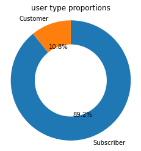

```python
# user type visualization
sorted_counts = df_ford['user_type'].value_counts()

plt.pie(sorted_counts, labels = sorted_counts.index, autopct='%1.1f%%', startangle = 90,
        counterclock = False, wedgeprops = {'width' : 0.4});
plt.axis('square')
plt.title('user type proportions')
```

According to the data, 89% of users are subscribers and %10 users are customers. The pie chart shows the distribution of user types above.

```python
#ages of members who rides bike most
member_age_order = df_ford['member_age'].value_counts().head(10)
member_age_order
```

```
31.0    10236
26.0     9325
30.0     8972
29.0     8658
28.0     8498
27.0     8250
32.0     8018
33.0     7973
25.0     7660
24.0     7423
Name: member_age, dtype: int64
```

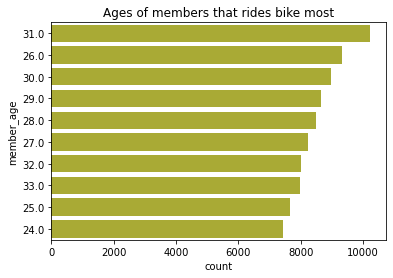

```python
#ages of members who rides bike most visualization
sb.countplot(data = df_ford, y = 'member_age', color = sb.color_palette()[8],
            order = (member_age_order.index));
plt.title('Ages of members that rides bike most')
```

I displayed the top ten ages mostly uses the service, and I want to see the least ages, too.

```python
#ages of members who rides bike least
least_order = df_ford['member_age'].value_counts().tail(10)
least_order
```

```
74.0    105
70.0     99
71.0     51
18.0     34
76.0     30
77.0     21
73.0     19
80.0     11
78.0      9
75.0      2
Name: member_age, dtype: int64
```

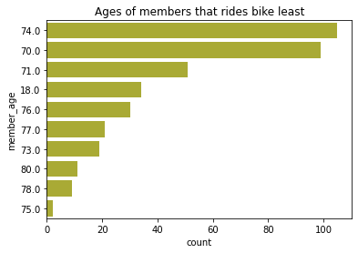

```python
# ages of members who rides bike least visualization
sb.countplot(data = df_ford, y = 'member_age', color = sb.color_palette()[8],
            order = (least_order.index));
plt.title('Ages of members that rides bike least')
```

The assumption I made while cleaning the data was people older than 80 do not use the service. It seems correct. The least usage is made by people over 70s. There is only one exception is that 18 years old.

```python
# descriptive statistics for numeric variables
df_ford.describe()
```

|  | duration_sec | start_station_id | start_station_latitude | start_station_longitude | end_station_id | end_station_latitude | end_station_longitude | bike_id | member_birth_year | duration_hour | duration_minutes | member_age |
| --- | --- | --- | --- | --- | --- | --- | --- | --- | --- | --- | --- | --- |
| count | 183220.000000 | 183023.000000 | 183220.000000 | 183220.000000 | 183023.000000 | 183220.000000 | 183220.000000 | 183220.000000 | 174955.000000 | 183220.000000 | 183220.000000 | 174955.000000 |
| mean | 726.394286 | 138.608180 | 37.771206 | -122.352626 | 136.283822 | 37.771411 | -122.352212 | 4472.654143 | 1984.878003 | 13.458362 | 11.614633 | 34.121997 |
| std | 1795.260417 | 111.779371 | 0.099629 | 0.117138 | 111.529675 | 0.099538 | 0.116715 | 1664.412719 | 9.875893 | 4.726178 | 29.922591 | 9.875893 |
| min | 61.000000 | 3.000000 | 37.317298 | -122.453704 | 3.000000 | 37.317298 | -122.453704 | 11.000000 | 1939.000000 | 0.000000 | 1.000000 | 18.000000 |
| 25% | 325.000000 | 47.000000 | 37.770083 | -122.412408 | 44.000000 | 37.770407 | -122.411726 | 3777.000000 | 1980.000000 | 9.000000 | 5.000000 | 27.000000 |
| 50% | 514.000000 | 104.000000 | 37.780760 | -122.398285 | 100.000000 | 37.781010 | -122.398279 | 4957.000000 | 1987.000000 | 14.000000 | 8.000000 | 32.000000 |
| 75% | 796.000000 | 239.000000 | 37.797280 | -122.286533 | 235.000000 | 37.797320 | -122.288045 | 5502.000000 | 1992.000000 | 17.000000 | 13.000000 | 39.000000 |
| max | 85444.000000 | 398.000000 | 37.880222 | -121.874119 | 398.000000 | 37.880222 | -121.874119 | 6645.000000 | 2001.000000 | 23.000000 | 1424.000000 | 80.000000 |

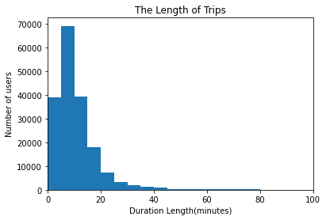

```python
# length of duration in minutes visualization
bins = np.arange(0, 100, 5)
plt.hist(data = df_ford, x= 'duration_minutes', bins = bins);
plt.xlim(0,100)
plt.title('The Length of Trips')
plt.xlabel('Duration Length(minutes)')
plt.ylabel('Number of users')
```

```python
df_ford['duration_minutes'].mean()
```

```
11.614632682021613
```

Unimodel , slightly right skewed. People generally use the service for between 5-15 minutes.

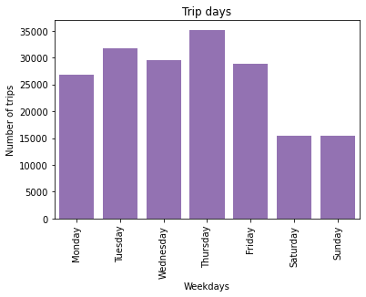

```python
# Weekdays for renting a bike visualization
base_color = sb.color_palette()[4]
cat_order = ['Monday', 'Tuesday', 'Wednesday', 'Thursday', 'Friday', 'Saturday', 'Sunday']
sb.countplot(data = df_ford, x = 'duration_day', order = cat_order, color = base_color)
plt.title('Trip days')
plt.xlabel('Weekdays')
plt.ylabel('Number of trips');
plt.xticks(rotation=90);
```

Bikes are rented mostly on Thursdays.

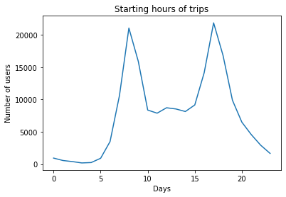

```python
#The time trips started visualization
time = df_ford.duration_hour.value_counts().sort_index().plot(kind = 'line').set(xlabel = 'Start Time of Duration')
plt.title('Starting hours of trips')
plt.xlabel('Days')
plt.ylabel('Number of users')
```

Bimodal distribution, as expected peaks at peak hours. Between 10:00 and 15:00 trip counts drops by a half.

```python
#Counting and ordering start station of trips
start_station_counts = df_ford['start_station_name'].value_counts().head(5)
start_station_order = start_station_counts.index
start_station_order
```

```
Index(['Market St at 10th St',
       'San Francisco Caltrain Station 2  (Townsend St at 4th St)',
       'Berry St at 4th St',
       'Montgomery St BART Station (Market St at 2nd St)',
       'Powell St BART Station (Market St at 4th St)'],
      dtype='object')
```

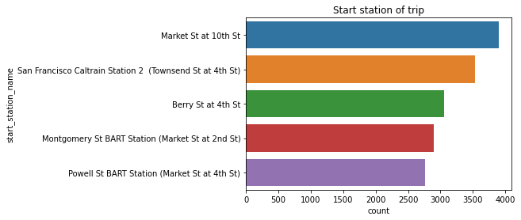

```python
#Start station of trip visualization
sb.countplot(data = df_ford, y = 'start_station_name',
            order = (start_station_order));
plt.title('Start station of trip')
```

The most two popular start stations are 'Market St at 100th St.' and 'San Francisco Caltrain Station 2'.

```python
#Counting and ordering end station of trips
end_station_counts = df_ford['end_station_name'].value_counts().head(5)
end_station_order = end_station_counts.index
end_station_order
```

```
Index(['San Francisco Caltrain Station 2  (Townsend St at 4th St)',
       'Market St at 10th St',
       'Montgomery St BART Station (Market St at 2nd St)',
       'San Francisco Ferry Building (Harry Bridges Plaza)',
       'Powell St BART Station (Market St at 4th St)'],
      dtype='object')
```

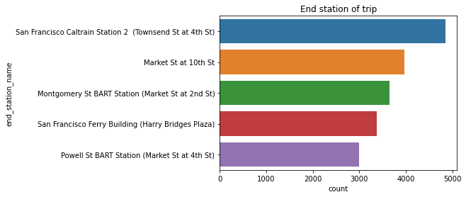

```python
#End station of trip visualization
sb.countplot(data = df_ford, y = 'end_station_name',
            order = (end_station_order));
#plt.xticks(rotation = 90);
plt.title('End station of trip')
```

The most two popular end stations are 'San Francisco Caltrain Station 2' and 'Market St at 100th St.'.

## Bivariate Exploration

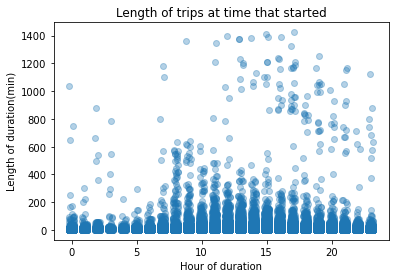

```python
sb.regplot(data = df_ford, x = 'duration_hour',
           y = 'duration_minutes', fit_reg = False,
           x_jitter = 0.2, y_jitter = 0.2,
           scatter_kws = {'alpha' : 1/3})
plt.xlabel('Hour of duration')
plt.ylabel('Length of duration(min)')
plt.title('Length of trips at time that started')
```

The plot suggests no correlation between duration length and duration hour. Two peaks I observed on duration hours are significant for the usage duration of bikes. However, it can be said that people prefer to ride in longer durations after 13:00.

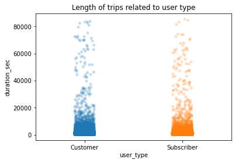

```python
#user type and duration time(seconds) relationship
sb.stripplot(x=df_ford["user_type"] , y=df_ford['duration_sec'] , jitter=True , alpha = 0.25)
plt.title('Length of trips related to user type')
```

From this plot, we can see that there is a non-monotanic relationship between customer type and duration length. Subscriber tends to take shorter trips than customers.

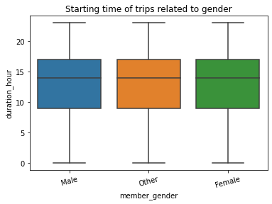

```python
#gender and the time trip started relationship
sb.boxplot(data= df_ford, x='member_gender', y='duration_hour');
plt.xticks(rotation = 15);
plt.title('Starting time of trips related to gender')
```

There is no relation between starting hour of duration and gender.

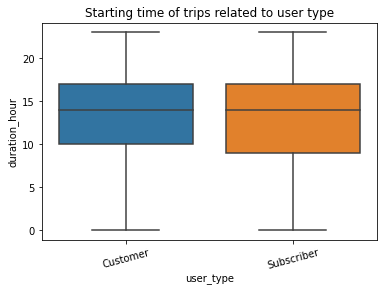

```python
#user type and the time trip started relationship
sb.boxplot(data= df_ford, x='user_type', y='duration_hour');
plt.xticks(rotation = 15);
plt.title('Starting time of trips related to user type')
```

First quartile(minimum) starting hour of duration for subscribers is earlier then customers. Their medians and maxs are approximately equal. We may say that subscribers rent in a more wide of range in a day, as starting to rent earlier. It is probably the time for going to office.

## Multivariate Exploration

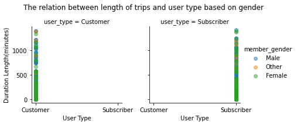

```python
# The relation between user type and duration length based on gender
m = sb.FacetGrid(data=df_ford ,col = 'user_type' , hue = 'member_gender')
m.map(plt.scatter , 'user_type','duration_minutes' , alpha = 0.5).add_legend()
m.set_xlabels('User Type' , size = 10)
m.set_ylabels('Duration Length(minutes)')
m.set_xticklabels()
m.fig.subplots_adjust(top=.8) #setting title to the top
m.fig.suptitle('The relation between length of trips and user type based on gender', size=12)
```

[figure not shown]

```python
# The relation between starting hour of trip and age of user based on customer type
c = sb.FacetGrid(data=df_ford ,col = 'member_gender' , hue = 'user_type')
c.map(plt.scatter , 'member_age','duration_hour' , alpha = 0.5).add_legend()
c.set_xlabels('Age')
c.set_ylabels('Duration hour')
c.set_xticklabels()
c.fig.subplots_adjust(top=.8) #setting title to the top
c.fig.suptitle('The relation between starting hour of trip and age of user based on customer type', size=12);
```

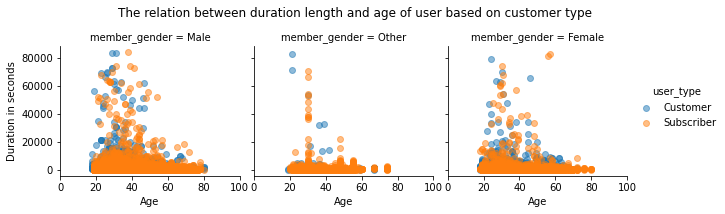

```python
# The relation between duration length and age of user based on customer type
a = sb.FacetGrid(data=df_ford ,col = 'member_gender' , hue = 'user_type')
a.map(plt.scatter , 'member_age','duration_sec' , alpha=0.5).add_legend()
a.set_xlabels('Age')
a.set_ylabels('Duration in seconds')
a.set_xticklabels()
a.fig.subplots_adjust(top=.8) #setting title to the top
a.fig.suptitle('The relation between duration length and age of user based on customer type', size=12);
```

The average of subscribers' ages are similar about durations for both duration hour and duration length on gender in case they are customers or subscribers.

```python
#duration day counts and order
duration_day_counts = df_ford['duration_day'].value_counts()
duration_day_order = duration_day_counts.index
duration_day_order
```

```
Index(['Thursday', 'Tuesday', 'Wednesday', 'Friday', 'Monday', 'Sunday',
       'Saturday'],
      dtype='object')
```

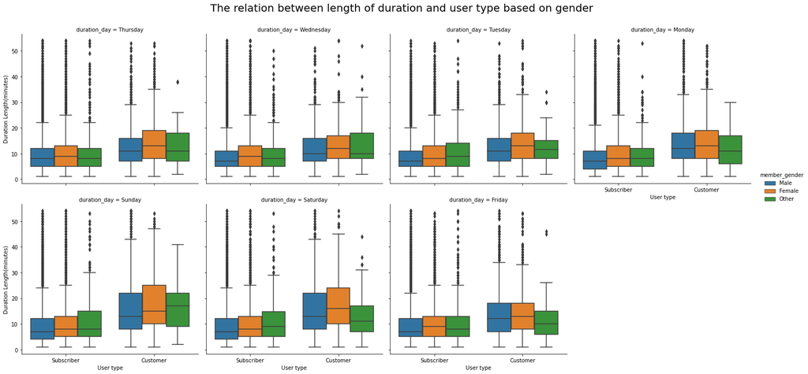

```python
#The relation between length of duration and user type based on gender
d = sb.factorplot(x="user_type", y="duration_minutes", col = "duration_day", hue="member_gender",col_wrap=4, kind="box",
                  data=df_ford.query('duration_minutes < 55'))
d.set_xlabels('User type')
d.set_ylabels('Duration Length(minutes)')
d.fig.subplots_adjust(top=.9) #setting title to the top
d.fig.suptitle('The relation between length of duration and user type based on gender', size=20);
```

Also, from the week-day comparison based on user_type and duration length represents a trend for both customer males and females are more tend to ride longer on the Weekends.